# The Effect of Bridging Social Capital on Social Mobility

Pei Yi Zhuo

2020-11-21

## Introduction

According to Chetty et al. (2014), there are areas of the country, such as Charlotte, North Carolina, where intergenerational upward mobility is particularly scarce as compared to the rest of the country. One factor that Chetty et al. (2014) identified as having a positive effect on social mobility is social capital, specifically “the strength of social networks and engagement in community organizations in local areas” (p. 1558).

One form of social capital that may be particularly influential for social mobility is bridging social capital or network ties between unlike people, such as people from different social class backgrounds. Of course, inter-class relationships are but one manifestation of bridging social capital. Relationships between immigrants and natives would be another example (Kanas et al., 2011; Lancee, 2010; Lancee, 2012). Such ties are regarded as potential dampeners on inequality by DiMaggio and Garip (2012). According to them, these relationships facilitate the dispersion of resources from elite social circles that would otherwise monopolize such advantages in the absence of any link to the less fortunate (DiMaggio & Garip, 2012). Thus, my hypothesis is that bridging social capital has a positive effect on intergenerational mobility.

In this paper, I investigate the question, What is the effect of relationships with high status people on social mobility? Specifically, I examine whether knowing a bachelor’s degree holder has a positive relationship with intergenerational occupational mobility. I also determine whether the size of this aforementioned effect is related to how long the respondent has known the bachelor’s degree holder. This is important because the effect of relationship length is indicative of the direction of the association between ties to high status people (bachelor’s degree holders in this case) and upward mobility. A positive relationship indicates that knowing bachelor’s degree holders longer amplifies upward mobility, suggesting that perhaps knowing a bachelor’s degree holder leads to upward mobility as opposed to the case where the upwardly mobile comes into contact with bachelor’s degree holders after mobility.

## Data

The data for this analysis comes from the General Social Survey (GSS). The GSS is a record of American social trends dating back to the 1970s (“The General Social Survey,” n.d.) and is administered by NORC at the University of Chicago (“About Our Name,” n.d.). According to the National Science Foundation (2007), the GSS provides data on “a nationally representative sample of non-institutionalized adults who speak either English or Spanish” (p. 11). Thus, the GSS is not representative of the entire U.S. population. GSS respondents have to be 18 or older; they have to be “non-institutionalized;” and they have to be able to speak either English or Spanish (National Science Foundation, 2007, p. 11). Moreover, prior to 2006, even Spanish speakers were absent from the target population of the GSS (National Science Foundation, 2007, p. 12-13).

Using GSS data, I will conduct an analysis involving a sample size of 1534 people, the total number of respondents in 1985. I am only able to analyze 1985 data because that is the year when the variables most relevant to my research question are available, `educ1` through `educ5` as well as `known1` through `known5`. These variables come from the social network module of the GSS, which provides information about “the people with whom [the respondent] discussed important matters” within the past 6 months (Smith et al., 2018). Information is available for five of the people the respondent lists, hence the numbering scheme of `educ1` through `educ5` and `known1` and `known5`. `educ1` through `educ5` describes the education level of each person within the respondent’s 5-person network. Likewise, `known1` through `known5` describes how long the respondent has known each person in their network. I will use `educ1` through `educ5` as markers of the socioeconomic status of the people in the respondent’s network.

## Methods

In order to use the GSS to address my research question, I revised my question to fit within the constraints of the variables available on the survey. My research question is an attempt to understand one direction of the relationship between high status ties and upward mobility, that is the impact of high-status ties on upward mobility as opposed to impact of upward mobility on high status ties. The directionality of this relationship cannot be ascertained by simply identifying the association between ties to high status people and upward mobility. Thus, data on the length of the relationship between the respondent and the high-status person, which is available on the GSS, is crucial. If the effect of having a high-status contact gets larger the longer you have this contact, we would have evidence (by no means definitive though) that the high status contact itself is behind the effect. In light of this, I rephrase my question to the following:

*What effect does the length of a relationship with a high-status person have on social mobility?*

To investigate this question, I first conducted exploratory data analysis to obtain observational evidence of the relationship between ties to high status people and upward mobility. For more robust results, I also created an ordinary least squares regression model and a logistic regression model so that a variety of control variables can be applied.

Before modeling can take place, I created two network variables: `educ` and `known`. These variables are named for the prefixes of the GSS variables from which they were derived. `educ` is the highest education level present in the respondent’s network. The longest length of time the respondent has known any person within their network with the aforementioned education level is captured by `known`. Thus, `known` describes how long the respondent has had contact with the most educated person in their network. I also created a variable to quantify socioeconomic mobility. The GSS scores the prestige of the respondent’s occupation as well as the respondent’s father’s occupation. I took the difference between the respondent’s score and their father’s score as a measure of the extent of socioeconomic mobility experienced by the respondent. This variable is the primary response variable of my models and is akin to the way in which Nikolaev and Burns (2014) operationalized occupational mobility.

The control variables that are included in my model can be divided into five categories: parental socioeconomic status, demographic characteristics, educational attainment, geography, and family structure. Parental socioeconomic status is included because those who come from families with higher socioeconomic statuses have, by definition, less room with which to advance. Thus, variables such as the father’s occupational prestige score, dummy variables to represent whether or not the father or the mother has a bachelor’s degree, and dummy variables for whether or not the respondent considered their family income at age 16 as having been above or below the average for American families are all included in the models. Demographic characteristics such as age, sex, and race are also included. (In their analysis of college majors and occupational status, Roksa and Levey (2010) also controlled for age, sex, and race.) Moreover, there is a dummy variable for whether or not the respondent has attained a bachelor’s degree due to the financial benefits of doing so (Oreopoulos & Petronijevic, 2013). Geography is considered because the work of Chetty et al. (2014) demonstrates that there is significant regional variation in rates of intergenerational upward mobility in the United States and because “geographic mobility is related to income and occupational status” (Markham, 1983). Finally, single parenthood was found to negatively correlate with upward mobility by Chetty et al. (2014).

## Results

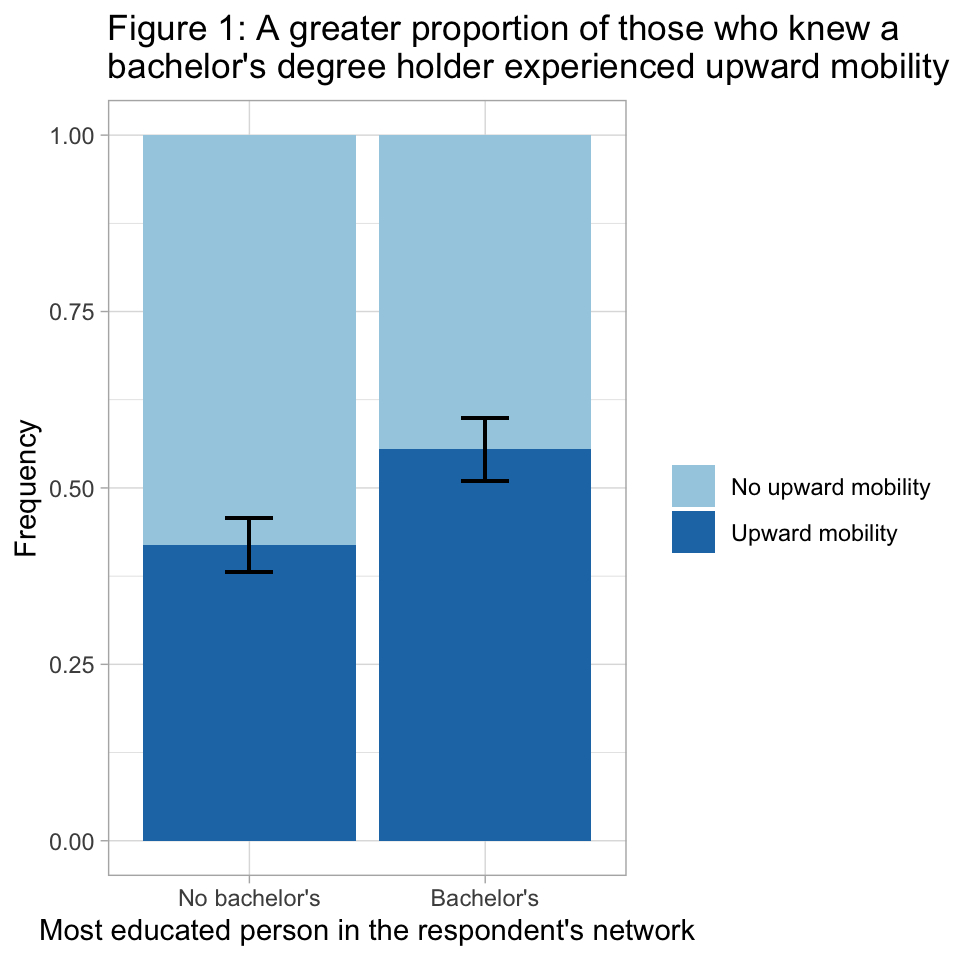

Exploratory data analysis supports my hypothesis that knowing a high-status person has a positive effect on upward mobility. As can be seen in Figure 1 above, a greater proportion of respondents who had a high-status tie (knew a bachelor’s degree holder) experienced upward mobility than respondents who did not have a high-status tie. Specifically, the difference is 0.136, and it is significant at the 0.05 level. However, this finding says nothing about the direction of the relationship between having high status ties and social mobility.

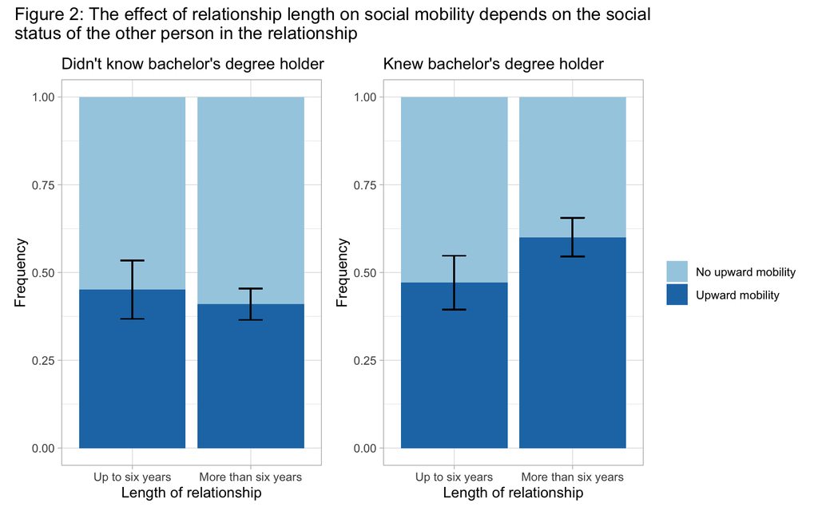

To obtain any sense of directionality, one must incorporate time into the analysis. After all, it is not hard to imagine a poor person who lacked high-status contacts in the past attaining high-status friends after achieving upward mobility. The rightmost plot in Figure 2 allows us to see whether there is evidence for the reverse, that high-status friends precedes upward mobility. Here, I only consider respondents who have a relationship with a high-status person (a bachelor’s degree holder). From the plot, it is apparent that a greater proportion of those who knew a high-status person for more than six years (who presumably are more likely to have known the high-status person prior to upward mobility than those who knew the high-status person for a shorter period of time) achieved upward mobility than those who only knew such a person for up to six years, a difference of 0.129. However, the difference in proportions is not statistically significant at the 0.05 level, just barely missing the mark. The difference is significant at the 0.1 level though. There thus appears to be a positive relationship between knowing a bachelor’s degree holder for a longer period of time and upward mobility.

Perhaps simply knowing the most educated person in your network for more than six years, regardless of whether they have a bachelor’s degree or not, is positively associated with upward mobility. We examine this possibility with the leftmost plot above where we take a look at only those respondents who had no bachelor’s degree holders in their network. If it is the length of the relationship that matters, then we would expect a greater proportion of those who knew the most educated person in their network for more than six years to have experienced upward mobility even if they do not hold a bachelor’s degree. This is not the case. Indeed, the reverse is true, a smaller proportion of those who knew the most educated person for more than six years experienced upward mobility compared with those who knew the non-graduate for up to six years. However, the difference is not statistically significant. Thus, if they do not have a bachelor’s degree, there appears to be no association between knowing the most educated person in your network for more than six years and upward mobility.

Of course, no variables were controlled for in any of the plots thus far described. Thus, these visualizations do not account for the possibility that confounding variables may actually lie at the heart of these findings. To account for such variables, modeling can be used. I created two different models, an ordinary least squares (OLS) regression model as well as a logistic regression model. These two models differ on the basis of their response variable. While the OLS model is intended to predict the difference between the respondent’s occupational prestige score and their father’s occupational prestige score, the logit model can be used to predict the probability that the respondent would have an occupational prestige score that is greater than their father’s. As a result of this difference in variable type, discrepancies between the two models can be expected.

Figure 3: Ordinary least squares regression model output

| Term | Estimate | Std. error | Statistic | p-value |
| --- | --- | --- | --- | --- |
| Intercept | 25.780 | 3.704 | 6.960 | 0*** |
| Has high status tie | 3.673 | 1.727 | 2.127 | 0.034* |
| Had tie for over 6 years | -1.240 | 1.258 | -0.985 | 0.325 |
| Father’s occupational prestige score | -0.920 | 0.036 | -25.685 | 0*** |
| Below average income at 16 | -1.123 | 1.257 | -0.894 | 0.372 |
| Above average income at 16 | 4.831 | 1.517 | 3.184 | 0.001** |
| Father has bachelor’s | -1.277 | 1.530 | -0.834 | 0.404 |
| Mother has bachelor’s | -0.364 | 1.609 | -0.226 | 0.821 |
| Age | 0.342 | 0.149 | 2.288 | 0.022* |
| Age squared | -0.003 | 0.002 | -1.997 | 0.046* |
| Is female | 0.137 | 0.778 | 0.176 | 0.86 |
| Is non-white | -2.982 | 1.432 | -2.082 | 0.038* |
| Has bachelor’s | 14.416 | 1.536 | 9.384 | 0*** |
| Lived in the south at 16 | -0.604 | 0.960 | -0.629 | 0.53 |
| Lived in rural area at 16 | -1.625 | 0.919 | -1.767 | 0.077 |
| Lived in city at 16 | 2.252 | 1.301 | 1.731 | 0.084 |
| Moved to different city in same state since 16 | 1.234 | 0.964 | 1.281 | 0.201 |
| Moved to different state since 16 | 2.181 | 0.953 | 2.289 | 0.022* |
| Single-parent household | -0.856 | 5.359 | -0.160 | 0.873 |
| Below average income at 16 and has bachelor’s | 1.447 | 2.704 | 0.535 | 0.593 |
| Above average income at 16 and has bachelor’s | -6.088 | 2.479 | -2.455 | 0.014* |
| Below average income at 16 and has high status tie | -0.343 | 2.172 | -0.158 | 0.875 |
| Above average income at 16 and has high status tie | -4.130 | 2.250 | -1.836 | 0.067 |
| Had high status tie for over 6 years | 4.474 | 1.747 | 2.560 | 0.011* |

*p < 0.05 **p < 0.01 ***p < 0.001

The output of the OLS model is shown in Figure 3. All five categories of control variables, parental socioeconomic status, demographic characteristics, educational attainment, geography, and family structure are included. A term representing the square of the `age` variable has been added to account for the nonlinear relationship between `age` and mobility. In total there are 23 variables in the model. However, the variables most relevant to my research question are whether or not the respondent has a high-status tie (The most educated person in their 5-person network is a bachelor’s degree holder.), whether or not the respondent has known the most educated person in their 5-person network for over six years, and the interaction between these two variables (the effect of knowing a bachelor’s degree holder for more than six years). The coefficients for these three variables are around 3.673, -1.24, and 4.474 respectively. Only knowing a bachelor’s degree holder and knowing a bachelor’s degree holder for over six years are statistically significant at the 0.05 level. The result that, if the respondent knows no bachelor’s degree holders, knowing the most educated person in a 5-person network for over six years does not have a significant impact on upward mobility is consistent with the exploratory data analysis. The regression output also expands on the EDA by showing that knowing a high-status tie for up to six years yields a positive effect on occupational mobility. Likewise, the variable most important for answering my research question, the interaction term that represents knowing a high-status tie for over six years, is positive and significant at the 0.05 level, indicating that knowing the high-status tie for a longer period of time (over six years vs. up to six years) further increases the extent of upward occupational mobility.

Figure 4: Logistic regression model output

| Term | Estimate | Std. error | Statistic | p-value |
| --- | --- | --- | --- | --- |
| Intercept | 3.340 | 0.818 | 4.083 | 0*** |
| Has high status tie | 0.091 | 0.367 | 0.247 | 0.805 |
| Had tie for over 6 years | -0.659 | 0.266 | -2.474 | 0.013* |
| Father’s occupational prestige score | -0.139 | 0.011 | -12.520 | 0*** |
| Below average income at 16 | 0.015 | 0.265 | 0.057 | 0.954 |
| Above average income at 16 | 0.615 | 0.315 | 1.950 | 0.051 |
| Father has bachelor’s | -0.895 | 0.382 | -2.344 | 0.019* |
| Mother has bachelor’s | 0.391 | 0.366 | 1.068 | 0.286 |
| Age | 0.080 | 0.032 | 2.464 | 0.014* |
| Age squared | -0.001 | 0.000 | -2.240 | 0.025* |
| Is female | 0.396 | 0.171 | 2.320 | 0.02* |
| Is non-white | -0.789 | 0.317 | -2.486 | 0.013* |
| Has bachelor’s | 2.544 | 0.390 | 6.515 | 0*** |
| Lived in the south at 16 | -0.397 | 0.207 | -1.922 | 0.055 |
| Lived in rural area at 16 | -0.419 | 0.195 | -2.155 | 0.031* |
| Lived in city at 16 | 0.552 | 0.294 | 1.879 | 0.06 |
| Moved to different city in same state since 16 | 0.300 | 0.211 | 1.427 | 0.154 |
| Moved to different state since 16 | 0.378 | 0.206 | 1.833 | 0.067 |
| Single-parent household | 0.427 | 1.722 | 0.248 | 0.804 |
| Below average income at 16 and has bachelor’s | -0.601 | 0.716 | -0.840 | 0.401 |
| Above average income at 16 and has bachelor’s | -1.024 | 0.569 | -1.801 | 0.072 |
| Below average income at 16 and has high status tie | 0.017 | 0.481 | 0.035 | 0.972 |
| Above average income at 16 and has high status tie | -0.785 | 0.483 | -1.628 | 0.104 |
| Had high status tie for over 6 years | 1.266 | 0.381 | 3.324 | 0.001*** |

*p < 0.05 **p < 0.01 ***p < 0.001

I also ran a logit model using the exact same variables as the OLS model. In the logit model output shown in Figure 4, the p-value of the interaction term is even smaller than the OLS model. Indeed, it is significant at the 0.001 level. However, the positive effect of knowing a bachelor’s degree holder is no longer significant at the 0.05 level, and there is also a significant negative effect of knowing the most educated person in the 5-person network for more than six years. However, since the coefficient of the interaction term is greater than the coefficient of knowing the most educated person for more than six years, knowing a bachelor’s degree holder for more than six years still yields a net positive effect on social mobility. This result does suggest that, if the respondent does not know a high-status person (bachelor’s degree holder), then knowing the highest status person in their network for more than six years has a negative effect on social mobility, contradicting both the OLS model as well as the exploratory data analysis. Both of these previous analyses indicated that if the respondent’s network lacks a bachelor’s degree holder, knowing the most educated person in the network affords no effect on social mobility.

## Discussion

My analysis has produced evidence to affirm my hypothesis that having a relationship with high-status people leads to greater social mobility. This result is consistent with other articles on bridging social capital/cross-class ties. Literature on this subject show that relationships that unite people from distinct backgrounds improve the outcomes of the less advantaged in terms of income/occupational status (Kanas et al., 2011; Lancee 2010; Lancee, 2012; and Zhang et al., 2011) as well as educational achievement (Lessard and Juvonen, 2019). However, to the best of my knowledge, no analysis has been conducted to investigate the role of bridging social capital on intergenerational social mobility. Other papers have found improvements across briefer time spans as opposed to intergenerational improvements.

Although my finding is consistent with a circumstance in which the educational level of people’s networks increases upward mobility, it ought not to be considered conclusive proof. Moreover, my analysis cannot explain the precise mechanism by which increased exposure to high status people leads to greater social mobility. Additionally, a significant portion of the 1985 sample of the GSS were not included in my models due to missing values. Indeed, my OLS and logit models use only 61.93% of the sample. Finally, to ascertain occupational mobility, I only had access to the occupational prestige score of the respondent’s father. According to Beller (2009), ignoring characteristics of the mother when analyzing mobility may produce inaccurate results.

With such limitations in mind, a potential policy response to my finding could be the expansion of national service programs, as proposed by former presidential candidate Pete Buttigieg, that seeks to bring together young people from all walks of life (Ismay, 2019). If the results of this paper were to hold, such a policy would increase upward mobility in America.

## Acknowledgements

I would like to thank Dr. Christopher A. Bail and Devin J. Cornell for their help on this project.

## Bibliography

“About Our Name.” NORC at the University of Chicago, https://www.norc.org/about/Pages/about-our-name.aspx. Accessed 23 Oct. 2020.

Beller, E. (2009). Bringing intergenerational social mobility research into the twenty-first century: Why mothers matter. *American Sociological Review*. 74(4), 507-528. https://doi.org/10.1177/000312240907400401

Chetty, R., Hendren, N., Kline, P., & Saez, E. (2014). Where is the land of opportunity? The Geography of intergenerational mobility in the United States. *Quarterly Journal of Economics*, 4(129), 1553-1623. https://doi.org/10.1093/qje/qju022

DiMaggio, P., & Garip, F. (2012). Network effects and social inequality. *Annual Review of Sociology*, 38, 93-118. https://doi.org/10.1146/annurev.soc.012809.102545

The General Social Survey. NORC at the University of Chicago, https://gss.norc.org. Accessed 23 Oct. 2020.

Kanas, A., van Tubergen, F., & Van der Lippe, T. (2011). The role of social contacts in the employment status of immigrants: A panel study of immigrants in Germany. *International Sociology*, 26(1), 95-122. https://doi.org/10.1177/0268580910380977

Lancee, B. (2010). The economic returns of immigrants’ bonding and bridging social capital: The case of the Netherlands. *International Migration Review*, 44(1), 202-226. https://doi.org/10.1111/j.1747-7379.2009.00803.x

Lancee, B. (2012). The economic returns of bonding and bridging social capital for immigrant men in Germany. *Ethnic and Racial Studies*, 35(4), 664-683. https://doi.org/10.1080/01419870.2011.591405

Lessard, L. M., & Juvonen, J. (2019). Cross-class friendship and academic achievement in middle school. *Developmental Psychology*, 55(8), 1666-1679. http://dx.doi.org/10.1037/dev0000755

Markham, W. T., Macken, P. O., Bonjean, C. M., & Corder, J. (1983). A note on sex, geographic mobility, and career advancement. *Social Forces*, 61(4), 1138-1146. https://doi.org/10.2307/2578283

National Science Foundation. (2007). *The General Social Survey (GSS): The next decade and beyond*. National Science Foundation. https://www.nsf.gov/pubs/2007/nsf0748/nsf0748.pdf

Nikolaev, B., & Burns, A. (2014). Intergenerational mobility and subjective well-being—Evidence from the general social survey. *Journal of Behavioral and Experimental Economics*, 53, 82-96. http://dx.doi.org/10.1016/j.socec.2014.08.005

Oreopoulos, P., & Petronijevic, U. (2013). Making college worth it: A review of research on the returns to higher education (NBER Working Paper No. 19053). Cambridge, MA: National Bureau of Economic Research. http://www.nber.org/papers/w19053

Palardy, G. J., (2013). High school socioeconomic segregation and student attainment. *American Educational Research Journal*, 50(4), 714-754. https://doi.org/10.3102/0002831213481240

Roksa, J., & Levey, T. (2010). What can you do with that degree? College major and occupational status of college graduates over time. *Social Forces*, 89(2), 389-415. https://doi.org/10.1353/sof.2010.0085

Ismay, J. (2019, July 3). Pete Buttigieg proposes national service programs for climate change and mental health. *The New York Times*. Retrieved from https://www.nytimes.com